# DATASCI 530 Assignment 3

# OpenAlex

September 27, 2026

Maxine Hakimi-Bulson

## OpenAlex

OpenAlex is a free database of research publications where one can get information such as a work’s title, publication year, citation count, authors, and their affiliated institutions. We will be using its API to search for works by title and compare the results. An API lets my Python code request information from a website.

## Summary of Findings

Overall, the results show that research using artificial intelligence syntax has grown exponentially and the authors writing these publications are affiliated with institutions globally. The title terms "artificial intelligence," "AI," "LLM," and "GPT" showed different rates of growth over time, highlighting how the choice of search term affects the results drastically. Research mentioning AI also spans several fields and has slightly change over the years. Computer science remained the most prominent field when comparing fields talking about AI in 2022 and 2026, while social sciences rose in ranking, suggesting an increasing importance on AI in 2026.

## Import Packages

First we will import the necessary packages to complete our analysis.

```python
import requests      # Requests data from an API
import json          # Handles JSON object
import jmespath      # Allows you to mor easily navigate JSON objects
import pandas as pd  # Handles data frames
import matplotlib.pyplot as plt
```

## Inquiry & Analysis

### 1. How many works have “artificial intelligence” in their titles?

I sent a request to OpenAlex Works API using title.search to restrict matches to work titles containing the phrase "artificial intelligence." I read 'meta["count"]' from the JSON response to get the total count for titles with the phrase "artificial intelligence."

```python
# url to search for titles that contain the phrase "artificial intelligence" in the title
url_openalex_ai = 'https://api.openalex.org/works?filter=title.search:"artificial intelligence"'

# send the request for the title search data
search_results_ai = requests.get(url_openalex_ai).json()

# browse keys in the first level
#print(search_results_ai.keys())

# use meta["count"] as it gives the number of all matching works ("results" only gives first page)
print(search_results_ai["meta"]["count"])

# quality check: confirm that "artificial intelligence" is in the title of one
#print(search_results_ai["results"][0]["title"])
```

```
332257
```

There are 332,257 works with "artificial intelligence" in their titles.

### 2. Restrict the analysis to works published since 2000 and group by the country of the authors’ affiliations. Produce a table that sorts the countries by the number of publications about artificial intelligence.

I kept the title search from (1) and added "from_publication_date:2000-01-01" to filter to works published since 2000. I also had to add "to_publication_date:2026-09-27" after realizing there are some works in OpenAlex that have publication dates later than the year 2026. I grouped the works by countries of their authors’ affiliations. The first response reached OpenAlex’s 200 group page limit, so I used cursor pagination and a while loop to collect all 212 country groups. I printed a table of my findings, sorting the count in descending order and displayed the top 10 countries with the most publications with "artificial intelligence" in the title since 2000.

```python
# url to search for titles that contain the phrase "artificial intelligence" in the title
# and filter to only include works published since 2000
url_openalex_ai_2000 = \
    'https://api.openalex.org/works?filter=title.search:"artificial intelligence",from_publication_date:2000-01-01,to_publication_date:2026-09-27'

# group by the country of the authors' affiliations
url_openalex_ai_2000_grouped = url_openalex_ai_2000 + '&group_by=authorships.countries'

# quality check: confirm the search groups by country
#first_response_ai_2000 = requests.get(url_openalex_ai_2000_grouped).json()
#print("Groups in first response:", len(first_response_ai_2000["group_by"]))
#print("Groups reported for that page:", first_response_ai_2000["meta"]["groups_count"])

# use cursor pagination to collect all remaining groups
country_groups_ai_2000 = []
cursor_ai_2000 = "*"
groups_per_page_ai_2000 = []

while cursor_ai_2000 is not None:
    page_ai_2000 = requests.get(
        url_openalex_ai_2000_grouped,
        params={"cursor": cursor_ai_2000}
    ).json()

    groups_on_page = page_ai_2000["group_by"]
    country_groups_ai_2000.extend(groups_on_page)
    groups_per_page_ai_2000.append(len(groups_on_page))
    cursor_ai_2000 = page_ai_2000["meta"]["next_cursor"]

# quality check: show pagination and the total number collected
#print(groups_per_page_ai_2000)
#print(len(country_groups_ai_2000))

# make results table
table_ai_2000_grouped = pd.DataFrame(country_groups_ai_2000)

# quality check: inspect the variables
#print(table_ai_2000_grouped.columns)

table_ai_2000_grouped = table_ai_2000_grouped[
    ["key_display_name", "count"]
]
# rename columns
table_ai_2000_grouped = table_ai_2000_grouped.rename(
    columns={
        "key_display_name": "Country",
        "count": "Publications"
    }
)
# sort by number of publications
table_ai_2000_grouped = table_ai_2000_grouped.sort_values(
    by="Publications",
    ascending=False
).reset_index(drop=True)

# display results table
display(
    table_ai_2000_grouped.head(10)
    .style
    .format({"Publications": "{:,.0f}"})
    .set_caption("Top 10 countries by publications with 'artificial intelligence' in the title (Since 2000)")
    .hide(axis="index")
)
```

Top 10 countries by publications with 'artificial intelligence' in the title (Since 2000)

| Country | Publications |
| --- | --- |
| United States | 37,059 |
| China | 30,015 |
| India | 24,851 |
| United Kingdom | 12,693 |
| Indonesia | 9,133 |
| Italy | 7,409 |
| Germany | 6,910 |
| Turkey | 6,631 |
| Russia | 5,928 |
| Canada | 5,888 |

Since 2000, authors from the United States have produced the most publications on artificial intelligence. Authors from China and India follow as the second and third most publications with "artifiical intelligence" in the title. Other countries with high counts of publications with "artificial intelligence" in the title are the United Kingdom, Indonesia, Italy, Germany, Turkey, Canada, and Russia all included in the top ten.

Note that this was not a semantic search but only a search for the exact words "artificial intelligence" in the title, so there could be more papers on artificial intelligence than listed in the table.

### 3. What are the titles of the 10 most highly cited papers on artificial intelligence since 2000? How many citations do they have? Who are the authors? What institutions are they affiliated with?

Ten most cited works with 'artificial intelligence' in the title since 2000

| Work | Title | Citations | Authors | Affiliated institutions |
| --- | --- | --- | --- | --- |
| 1 | High-performance medicine: the convergence of human and artificial intelligence | 10,257 | E. J. Topol | Scripps Research Institute |
| 2 | Explainable Artificial Intelligence (XAI): Concepts, taxonomies, opportunities and challenges toward responsible AI | 10,108 | A. Barredo Arrieta; N. Díaz-Rodríguez; J. Del Ser; A. Bennetot; S. Tabik; A. Barbado; S. García; S. Gil-López; et al. | Tecnalia; Institut national de recherche en sciences et technologies du numérique; École Nationale Supérieure de Techniques Avancées; additional institutions |
| 3 | Systematic review of research on artificial intelligence applications in higher education – where are the educators? | 6,814 | O. Zawacki‐Richter; V. I. Marín; M. Bond; F. Gouverneur | Carl von Ossietzky Universität Oldenburg |
| 4 | Peeking Inside the Black-Box: A Survey on Explainable Artificial Intelligence (XAI) | 6,278 | A. Adadi; M. Berrada | Sidi Mohamed Ben Abdellah University |
| 5 | Proceedings of the 19th International Joint Conference on Artificial Intelligence | 5,781 | J. M. Pujol; J. Delgado; R. Sangüesa; A. Flache | Not listed for any author |
| 6 | Explanation in artificial intelligence: Insights from the social sciences | 5,253 | T. Miller | The University of Melbourne |
| 7 | Artificial intelligence in healthcare: past, present and future | 4,898 | F. Jiang; Y. Jiang; H. Zhi; Y. Dong; H. Li; S. Ma; Y. Wang; Y. Wang; et al. | University of Hong Kong; Capital Medical University; Beijing Tian Tan Hospital; additional institutions; not listed for some authors |
| 8 | Artificial Intelligence (AI): Multidisciplinary perspectives on emerging challenges, opportunities, and agenda for research, practice and policy | 4,523 | Y. Kumar Dwivedi; L. Hughes; E. Ismagilova; G. Aarts; C. R. Coombs; T. Crick; Y. Duan; R. Dwivedi; et al. | Prin. L. N. Welingkar Institute of Management Development and Research; Swansea University; University of Bradford; additional institutions; not listed for some authors |
| 9 | BNAI, NO-TOKEN, and MIND-UNITY: Pillars of a Systemic Revolution in Artificial Intelligence | 4,266 | J. Wei; X. Wang; D. Schuurmans; M. Bosma; B. Ichter; F. Xia; E. H.; Q. Viet Le; et al. | Google (United States); not listed for some authors |
| 10 | Artificial Intelligence in Education: A Review | 3,974 | L. Chen; P. Chen; Z. Lin | Yango University; Fuzhou University |

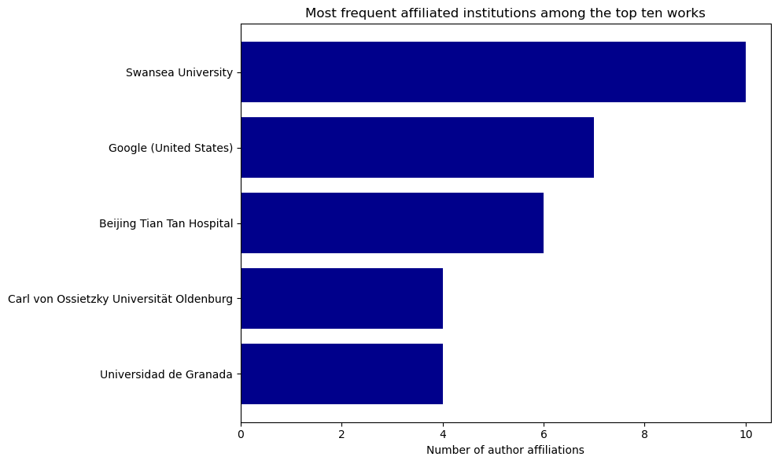

```python
# top ten works, authors, institutions, and affiliation frequencies
url_openalex_ai_2000_cited = (
    url_openalex_ai_2000 + '&sort=cited_by_count:desc'
)
search_results_ai_2000_cited = requests.get(
    url_openalex_ai_2000_cited
).json()
top10_works_ai_2000 = search_results_ai_2000_cited["results"][:10]

work_rows = []
institution_counts = {}

for work_number, work in enumerate(top10_works_ai_2000, start=1):
    author_names = []
    work_institutions = []
    missing_affiliation = False

    for authorship in work["authorships"]:
        full_name = authorship["author"]["display_name"]

        # abbreviate names
        if "," in full_name:
            surname, given_name = full_name.split(",", 1)
            given_name = given_name.strip()
            short_name = surname.strip()
            if given_name:
                short_name = given_name[0] + ". " + short_name
        else:
            name_parts = full_name.split()
            short_name = full_name
            if len(name_parts) > 1:
                short_name = name_parts[0][0] + ". " + " ".join(name_parts[1:])

        author_names.append(short_name)

        if not authorship["institutions"]:
            missing_affiliation = True

        # count each institution once per author
        author_institutions = []

        for institution in authorship["institutions"]:
            name = institution["display_name"]

            if name not in work_institutions:
                work_institutions.append(name)

            if name not in author_institutions:
                author_institutions.append(name)
                if name not in institution_counts:
                    institution_counts[name] = 0
                institution_counts[name] += 1

    # shorten only the author and institution columns
    author_text = "; ".join(author_names[:8])
    if len(author_names) > 5:
        author_text += "; et al."

    institution_text = "; ".join(work_institutions[:3])
    if len(work_institutions) > 3:
        institution_text += "; additional institutions"

    if not work_institutions:
        institution_text = "Not listed for any author"
    elif missing_affiliation:
        institution_text += "; not listed for some authors"

    work_rows.append({
        "Work": work_number,
        "Title": work["title"],
        "Citations": work["cited_by_count"],
        "Authors": author_text,
        "Affiliated institutions": institution_text
    })

table_ai_2000_concise = pd.DataFrame(work_rows)

display(
    table_ai_2000_concise.style
    .format({"Citations": "{:,.0f}"})
    .hide(axis="index")
    .set_caption(
        "Ten most cited works with 'artificial intelligence' "
        "in the title since 2000"
    )
)

# plot the ten most frequent institutions across all author affiliations (bar chart)
institution_table = pd.DataFrame(
    list(institution_counts.items()),
    columns=["Institution", "Author affiliations"]
)

top_institutions = institution_table.sort_values(
    ["Author affiliations", "Institution"],
    ascending=[False, True]
).head(5)

plt.figure(figsize=(10, 6))
plt.barh(
    top_institutions["Institution"],
    top_institutions["Author affiliations"],
    color="darkblue"
)
plt.gca().invert_yaxis()
plt.xlabel("Number of author affiliations")
plt.title("Most frequent affiliated institutions among the top ten works")
plt.tight_layout()
plt.show()
```

The most cited paper with "artificial intelligence" in the title is called, "High-performance medicine: the convergence of human and artificial intelligence" with 10,257 citations. In second place is the paper, "Explainable Artificial Intelligence (XAI): Concepts, taxonomies, opportunities and challenges toward responsible AI" with 10,108 citations. The third ranked paper is titled, "Systematic review of research on artificial intelligence applications in higher education - where are the educators?" with 6,814 citations. The ten highly cited works cover several areas, including explainable AI, healthcare, and education.

There is a large range of number of authors per paper, with the highest-cited paper only having one author, Eric J. Topol (Scripps Research Institute), to papers such as "Artificial Intelligence (AI): Multidisciplinary perspectives on emerging challenges, opportunities, and agenda for research, practice and policy" with 35 authors. The original table revealed some authors are affiliated with multiple institutions listed, while others have no affiliations listed.

### 4. How has the number of publications with the phrase “artificial intelligence” changed year-to-year since 2000? How does this compare to the use of the terms “LLM” and “GPT”? Repeat the year-to-year analysis for another keyword of your choice.

### Additional key word: "AI"

I compare the following terms in works titles: “artificial intelligence,” “LLM,” “GPT,” and my chosen additional term, “AI.” I restricted publication dates from January 1st, 2000 to the current date, September 27th, 2026. I used 'group_by=publication_year' to group the counts of each phrase by year. I converted the four JSON group lists to data frames, changed the year values to integers, and merged the counts by 'year' so all four terms would be in the same data frame for analysis. I plotted the four yearly series as colored lines with the term on its respective line.

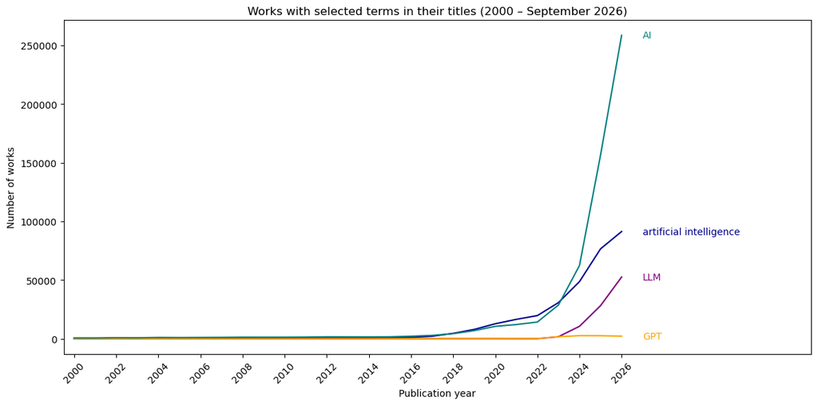

```python
# the four terms we will be comparing
terms = ["artificial intelligence", "LLM", "GPT", "AI"]
yearly_groups = {}

for term in terms:
    url_term_yearly = (
        f'https://api.openalex.org/works?filter=title.search:"{term}",'
        'from_publication_date:2000-01-01,'
        'to_publication_date:2026-09-27'
        '&group_by=publication_year'
    )
    search_results_term = requests.get(url_term_yearly).json()
    yearly_groups[term] = search_results_term["group_by"]
    #print(term, len(yearly_groups[term])) #quality check

# turn each term’s groups into a small DataFrame and merge them on year
table_yearly_terms = pd.DataFrame({"Year": range(2000, 2027)})

for term in terms:
    table_term = pd.DataFrame(yearly_groups[term])

    table_term = table_term[["key", "count"]].rename(
        columns={"key": "Year", "count": term}
    )
    table_term["Year"] = table_term["Year"].astype(int)

    table_yearly_terms = table_yearly_terms.merge(
        table_term, on="Year", how="left"
    )

# quality checks:
#print(table_yearly_terms.shape)
#print(table_yearly_terms.isna().sum())
#display(table_yearly_terms)

# plot line graph
plt.figure(figsize=(12, 6))

colors = ["darkblue", "purple", "orange", "teal"]

for term, color in zip(terms, colors):
    plt.plot(
        table_yearly_terms["Year"],
        table_yearly_terms[term],
        label=term,
        color=color
    )

plt.title("Works with selected terms in their titles (2000 – September 2026)")
plt.xlabel("Publication year")
plt.xticks(range(2000, 2027, 2), rotation=45)
plt.xlim(1999.5, 2026.8)
plt.ylabel("Number of works")
# label each line beside its 2026 value
for term, color in zip(terms, colors):
    count_2026 = table_yearly_terms[term].iloc[-1]
    plt.text(2027, count_2026, term, color=color, va="center")

plt.xlim(1999.5, 2035)  # leave room for the labels
plt.tight_layout()
plt.show()
```

Since 2000, the number of publications with the phrase "artificial intelligence" had stayed low in the 2000's and early 2010's. In 2020, the number rose to 12,822, and it kept increasing exponentially with 76,677 in 2025 and 90,590 publications so far in 2026.

Comparing this to the use of the terms "LLM" and "GPT", these terms were not used as much as "artificial intelligence" in publication titles from 2000-2022. In 2023, both terms were used over 1,000 times in titles, and "GPT" usage in titles has not increased much since then compared to "LLM" exponentially increasing to 10,865 in 2024 and 52,628 in 2026 so far.

Comparing to the keyword "AI", the term has exponentially increased in title appearances the same time that "artificial intellegence" became a more popular phrase, which makes sense as "AI" is the abbreviation for "artificial intelligence." Yet, "AI" is seen in titles far more than its equivalent phrase "artificial intelligence," surpassing it in 2024 in 62,651 titles and the number of titles with "AI" in 2026 so far is 256,642.

Thus, "AI" is the most popular term used of the four and has exponentially grown in usage, especially this year, with "artificial intelligence" following behind it with much less frequcency but still a significant amount. "LLM" is used half as much as "artificial intelligence," and "GPT" remains an unpopular phrase in titles to-date.

## New Insights

### 5. Compute an additional table or figure not included in the questions above.

### Which research fields dominate the discussion of AI in 2022 and 2026?

I compare the rankings of research fields among works with “AI” in their titles, using all publications from 2022 and publications from January 1, 2026 through September 27, 2026. I chose this question to investigate whether the research fields most prominently discussing AI changed between these two periods.

To answer this question, I used the OpenAlex Works API to search for works with “AI” in their titles. I filtered the results separately for each period and grouped them by the research field associated with each work’s primary topic. I converted the field counts into DataFrames and merged them by field. I ranked the fields within each year by their number of matching works and created a bump chart displaying fields in the top five of either year. Note that the comparison uses a full year for 2022 and a partial year for 2026 (up to Semptember 27th).

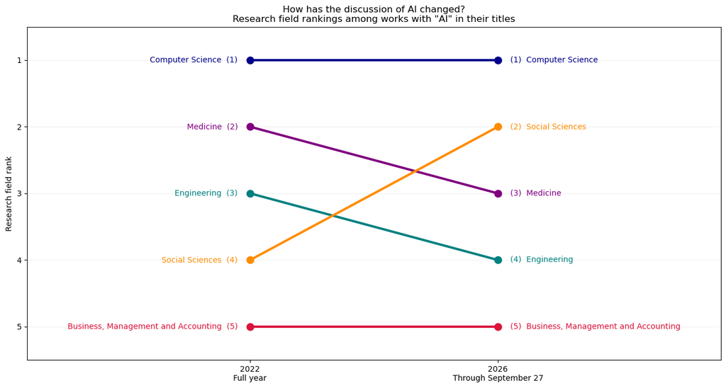

```python
# question 5: How has the discussion of AI changed from 2022 to 2026?
years_q5 = [2022, 2026]
field_tables = {}

for year in years_q5:
    if year == 2022:
        end_date = "2022-12-31"
    else:
        end_date = "2026-09-27"

    url_q5 = (
        'https://api.openalex.org/works?filter=title.search:"AI",'
        f'from_publication_date:{year}-01-01,'
        f'to_publication_date:{end_date}'
        '&group_by=primary_topic.field.id'
        '&per_page=200'
    )

    search_results_q5 = requests.get(url_q5).json()

    table_field = pd.DataFrame(search_results_q5["group_by"])
    table_field = table_field[["key_display_name", "count"]].rename(
        columns={
            "key_display_name": "Field",
            "count": f"Works {year}"
        }
    )

    field_tables[year] = table_field

# merge on 'field'
table_q5 = field_tables[2022].merge(
    field_tables[2026],
    on="Field",
    how="outer"
)

table_q5 = table_q5.fillna(0)

for year in years_q5:
    table_q5[f"Works {year}"] = table_q5[f"Works {year}"].astype(int)

    # highest count gets rank 1; equal counts receive equal ranks
    table_q5[f"Rank {year}"] = table_q5[f"Works {year}"].rank(
        ascending=False, method="min"
    ).astype(int)

# show top 5 ranked each year
chart_q5 = table_q5[
    (table_q5["Rank 2022"] <= 5) |
    (table_q5["Rank 2026"] <= 5)
].copy()

chart_q5 = chart_q5.sort_values("Rank 2022").reset_index(drop=True)


chart_q5["Rank improvement"] = (
    chart_q5["Rank 2022"] - chart_q5["Rank 2026"]
)

# quality checks
#print(table_q5.shape)
#print(table_q5.isna().sum())
#display(chart_q5)



# display results in a bump chart:
plt.figure(figsize=(13, 7))

colors = [
    "darkblue", "purple", "teal", "darkorange", "crimson",
    "forestgreen", "sienna", "deeppink", "slateblue", "gray"
]

for i, row in chart_q5.iterrows():
    color = colors[i]
    rank_2022 = row["Rank 2022"]
    rank_2026 = row["Rank 2026"]

    plt.plot(
        [0, 1],
        [rank_2022, rank_2026],
        color=color,
        marker="o",
        linewidth=3,
        markersize=9
    )

    plt.text(
        -0.05, rank_2022,
        f'{row["Field"]}  ({rank_2022})',
        color=color,
        ha="right",
        va="center"
    )

    plt.text(
        1.05, rank_2026,
        f'({rank_2026})  {row["Field"]}',
        color=color,
        ha="left",
        va="center"
    )

largest_rank = max(
    chart_q5["Rank 2022"].max(),
    chart_q5["Rank 2026"].max()
)

plt.xticks([0, 1], ["2022\nFull year", "2026\nThrough September 27"])
plt.yticks(range(1, largest_rank + 1))
plt.ylim(largest_rank + 0.5, 0.5)  # Rank 1 appears at the top
plt.xlim(-0.9, 1.9)
plt.ylabel("Research field rank")
plt.title(
    'How has the discussion of AI changed?\n'
    'Research field rankings among works with "AI" in their titles'
)
plt.grid(axis="y", alpha=0.2)
plt.tight_layout()

plt.show()
```

### 6. What do we learn from this new table or figure?

From the bumpchart, we see how research field rankings changed among works with “AI” in their titles. Computer science remained first over time, while social sciences moved from fourth in 2022 to second in 2026. Medicine moved from second to third and engineering moved from third to fourth. Business, management and accounting remained fifth over time. This is interesting as social sciences now includes more "AI" terms in their titles than the engineering field, showing its significance today.